# Analisis de dataset: Youtube Trending Video Dataset

Mauricio Campos, Jonathan Jara y Sebastián Pardo

8 de Abril de 2022

# Introducción

YouTube es una aplicación web que ofrece servicios para compartir y hacer streaming de videos bajo demanda o en directo. Es una filial de Google LLC, y sin duda una de las aplicaciones mas reconocidas y utilizadas a nivel mundial, de acuerdo con Statista, YouTube es la 2da red social mas popular a enero de 2022 [1], con cerca de 2,6 mil millones de usuarios activos mensualmente y una proyeccion de 2,8 mil millones de usuarios para el año 2025 [2]. Cada minuto se suben a esta plataforma mas de 500 horas de contenido de videos [3], y en este mismo tiempo se consumen alrededor de 700 horas de contenido multimedia [4].

De acuerdo con Google “la pestaña de tendencias de YouTube permite que los usuarios descubran las novedades de YouTube” [5]. Esta es una lista común compuesta de videos actuales que se muestra a todos los usuarios de un mismo país. YouTube mantiene listas de tendencias diferentes para cada país, las cuales actualiza con una frecuencia de 15 minutos. Si bien Google no ha hecho público el método para calcular las listas de tendencias, ha comunicado que buscan seleccionar videos que representen la actualidad de YouTube y sean relevantes para los usuarios del país correspondiente. Algunos de los factores que tienen en cuenta son:

- La cantidad de tiempo que lleva el video en la plataforma.
- Las visitas del video.
- El lugar o página web del que provienen las visitas.
- La rapidez con la que el video acumula visitas.
- El rendimiento del video en comparación a videos anteriores del mismo canal.

En base a estos criterios, es posible que se encuentren videos con bajas visitas en posiciones altas de la lista, si estas se comparan con otros videos de la misma lista.

El conjunto de datos seleccionado, [**YouTube Trending Video Dataset (updated daily)**](https://www.kaggle.com/datasets/rsrishav/youtube-trending-video-dataset/versions/610) contiene la información de estas listas de tendencias de 11 países: Brasil, Canadá, Alemania, Francia, Gran Bretaña, India, Japón, Corea del sur, México, Rusia y Estados Unidos. Algunos de los datos que incluye son el título del video, la fecha de subida del video, la cantidad de likes y de visitas, etc. El conjunto de datos es actualizado con una frecuencia diaria y se agregan hasta 200 videos nuevos en las listas de tendencias por día. Se utilizará la versión 610 del conjunto de datos, la cual contiene datos actualizados hasta el día 7 de Abril de 2022.

El estudio de este conjunto de datos resulta interesante, ya que al ser datos de una aplicación tan grande se tienen datos que incluyen la interacción de miles de millones de personas a escala global. Para esto el creador del conjunto de datos propone algunos usos:

- Análisis de sentimientos.
- Categorizar los videos basados en sus comentarios o estadísticas.
- Entrenar algoritmos de Machine Learning para generar comentarios.
- Analizar que factores afectan a la popularidad de un video.
- Análisis estadísticos a lo largo del tiempo.

Añadiendo a estas propuestas, puede resultar interesante el estudio de estos datos para encontrar todo tipo de relaciones entre los datos de cada video y el entorno de YouTube, por ejemplo:

- Determinar factores diferenciadores y comunes en las portadas de los videos en tendencia.
- Identificar los tópicos que mejor funcionan para un tema específico (salud, deporte, juegos, etc.).
- Encontrar nichos de contenido que estén en crecimiento.
- Estudiar las mejores formas de estructurar el título de un video para aumentar las visualizaciones.
- Identificar las preferencias de cada país respecto del contenido consumido.

Otra área que resulta interesante explorar es automatizar la generación de alguno de los atributos del conjunto de datos, como la miniatura, el título o la descripción. Finalmente, la predicción del rendimiento de un video (visualizaciones, likes, dislikes) es otra razón que hace interesante el estudio de este conjunto de datos.

# Análisis exploratorio del conjunto de datos

Los datos a analizar corresponden a los trendings de YouTube para el país de México, separado en dos dataset, uno que corresponde al principal, y un segundo dataset con información de las categorías disponibles para cada video.

Se comenzará cargando el dataset principal a un dataframe:

```r
mx_dataset <- read.csv("./dataset/MX_youtube_trending_data.csv", encoding = "UTF-8")
head(mx_dataset, n = 20)
```

|  | video_id | title | publishedAt | channelId | channelTitle | categoryId | trending_date | tags | view_count | likes | dislikes | comment_count | thumbnail_link | comments_disabled | ratings_disabled | description |
| --- | --- | --- | --- | --- | --- | --- | --- | --- | --- | --- | --- | --- | --- | --- | --- | --- |
| 1 | SsWHMAhshPQ | Ovi x Natanael Cano x Aleman x Big Soto - Vengo De Nada [Official Video] | 2020-08-11T23:00:10Z | UC648rgJOboZlgcDbW00vTSA | Rancho Humilde | 10 | 2020-08-12T00:00:00Z | Vengo De Nada\|Aleman\|Ovi\|Big Soto\|Trap\|Ovi Natanel Cano Big Soto Aleman\|Nata Aleman\|Ovi Vengo De Nada\|Natanael Cano Vengo De Nada\|Aleman Vengo De Nada\|Big Soto Vengo De Nada\|Natanael Cano\|… | 741028 | 113999 | 4380 | 5620 | https://i.ytimg.com/vi/SsWHMAhshPQ/default.jpg | False | False | Vengo De Nada - Ovi x Natanael Cano x Aleman x Big SotoDirected by Lalo The GiantExecutive Producer Jimmy Humildehttp://Instagram.com/Ovi_Oficialhttp://Instagram.com/Natanael_Canohttp://Instagram.com/… |
| 2 | JOaeND0xUNk | Belinda y Christian Nodal cantan De los besos que te di. ¡Revive el momento! \| La Voz Mexico | 2020-08-11T18:03:06Z | UCNVrBkfp4_TG9x4h5kvLeAQ | TV Azteca | 24 | 2020-08-12T00:00:00Z | tv azteca\|videos de tv azteca\|azteca uno\|en sus batallas\|desde casa\|azteca videos\|azteca digital\|entretenimiento tv azteca\|entretenimiento\|belinda y nodal\|nodal\|christian nodal\|belinda\|be… | 402507 | 8102 | 831 | 803 | https://i.ytimg.com/vi/JOaeND0xUNk/default.jpg | False | False | Encendieron el escenario de La Voz. TV AztecaTe llevamos lo mejor de la televisión por internet, entreteniendo e informando a los mexicanos.Bienvenido a https://www.tvazteca.com/ |
| 3 | SV91jnGs--s | ¿QUIÉN HACE LOS MEJORES NUGGETS? \| EL GUZII | 2020-08-11T19:57:02Z | UCuGn3ioftOo6jvHE1YK4Bfw | El Guzii | 26 | 2020-08-12T00:00:00Z | El Guzii\|Guzzi\|Guzy\|Guzii Style\|Recetas Divertidas\|Jairo Macizo\|Cocina Lab\|Sabores del Alma\|Cocina\|Miskiri Miskiri\|calificando nuggets\|calificando comida rápida\|chicken nuggets\|nuggets de… | 735044 | 62188 | 1053 | 4100 | https://i.ytimg.com/vi/SV91jnGs--s/default.jpg | False | False | Si tienes 10 kg de sobre peso tal vez te haz preguntado quién hace los mejores Nuggets de Pollo. Pues en éste video El Guzii te dice cuáles son. ¿Qué otras cosas podemos calificar? Suscríbete para ver… |
| 4 | QgX0zn5nMyk | Martha Figueroa se disculpa públicamente con Nicolás, hijo de Erika Buenfil \| Hoy | 2020-08-11T15:57:47Z | UCJPd6seu4JK4PZjVVTWb0QA | Hoy | 24 | 2020-08-12T00:00:00Z | Televisa\|Televisa espectaculos\|programa hoy televisa\|Programa Hoy\|elenco programa hoy\|videos programa hoy\|programa hoy 2020\|Andrea Legarreta\|Galilea Montijo\|Raúl Araiza\|Andrea Escalona\|#Con… | 521751 | 4680 | 3129 | 2285 | https://i.ytimg.com/vi/QgX0zn5nMyk/default.jpg | False | False | Mira aquí el contenido exclusivo que tenemos para ti: https://bit.ly/ProgramaHoyMartha Figueroa se disculpa con Nicolás, el hijo de Erika Buenfil, por la polémica que desató el fin de semana durante e… |
| 5 | cKaM19oAwBM | MAQUILLAJE PARA KIMBERLY LOAIZA✨ RESISTENTE AL AGUA 💧 Victor Guadarrama | 2020-08-11T21:55:08Z | UCs5w0QCxsEWz83vuQyOCnuA | Victor Guadarrama | 26 | 2020-08-12T00:00:00Z | MAQUILLAJE\|CELEBS\|ARTE\|MAKEUP\|PESTAÑAS\|KIMBERLYLOAIZA\|XIMENANAVARRETE\|MANELYK\|MARISOLGONZALES\|BELINDA\|ACAPULCOSHORE\|NINELCONDE\|TUTORIAL\|OJOS\|LABIOS\|BEAUTYVLOG\|COSMETICOS\|NOVIAS\|MAQUI… | 168118 | 24551 | 537 | 782 | https://i.ytimg.com/vi/cKaM19oAwBM/default.jpg | False | False | No olvides suscribirte y activar la campanita de notificaciones para que no te pierdas las próximas sorpresas. Compartenos tu look con este maquillaje en nuestras redes. Comenta que más te gustaría ve… |
| 6 | zU5lgsAKIIA | NOVIO VS. NOVIA - MaiLu | 2020-08-11T20:18:23Z | UCj4HkE5zO2aSU_LUv4fHB8A | MaiLu | 22 | 2020-08-12T00:00:00Z | lulu99\|novio de lulu99\|lulu y su novio\|maicol y luisa\|tag del novio\|novio\|lulu 99\|99\|lulu99 y su novio canal\|mailu\|mai lu\|pareja\|novios\|YOLO aventuras\|sandra cires\|24 horas\|esposados\|… | 989033 | 157522 | 2060 | 18314 | https://i.ytimg.com/vi/zU5lgsAKIIA/default.jpg | False | False | Hola MaiLutubers, bienvenidos al nuestro canal! En donde compartiremos todas nuestras aventuras juntos como pareja. En el video de hoy les traemos un NOVIO VS. NOVIA!! El reto de quien conoce mejor al… |
| 7 | p7WtYeowOEY | LA VENGANZA ES DULCE 😳 //CEVICHURRO VS TRIKI TRIKI 🤡// LA GUERR@ CONTINÚA 😂// parte 8 | 2020-08-12T01:00:04Z | UCUhXAsbSWi7s34-imeLyatg | SOY TRIKI TRIKI | 22 | 2020-08-12T00:00:00Z | Triki triki\|Payaso triki trki\|Soy triki triki | 64858 | 6327 | 110 | 437 | https://i.ytimg.com/vi/p7WtYeowOEY/default.jpg | False | False | el video anterior este en el canal de los cevichurros https://youtu.be/oTnUAsi8xio MI INSTAGRAM... https://www.instagram.com/payasotrikitriki/ MI PAGINA .... https://www.facebook.com/Triki-Triki-ofici… |
| 8 | M9Pmf9AB4Mo | Apex Legends \| Stories from the Outlands – “The Endorsement” | 2020-08-11T17:00:10Z | UC0ZV6M2THA81QT9hrVWJG3A | Apex Legends | 20 | 2020-08-12T00:00:00Z | Apex Legends\|Apex Legends characters\|new Apex Legend\|Apex Legends Rampart\|Apex Legends Season 6\|Apex Legends Boosted\|Battle Pass\|Season 6 Battle Pass\|Apex Legends new season\|Apex Legends game… | 2381688 | 146744 | 2794 | 16557 | https://i.ytimg.com/vi/M9Pmf9AB4Mo/default.jpg | False | False | While running her own modding shop, Ramya Parekh (aka Rampart) built her rep in underground gauntlet circuits. But success has a way of making enemies. Good thing she knows how to use all those fancy … |
| 9 | 8PaPyFpt3FE | ¡Erika Buenfil enfrenta a Pepillo Origel y pide respeto para su hijo! \| Hoy | 2020-08-10T17:13:40Z | UCJPd6seu4JK4PZjVVTWb0QA | Hoy | 24 | 2020-08-12T00:00:00Z | Televisa\|Televisa espectaculos\|programa hoy televisa\|Programa Hoy\|elenco programa hoy\|videos programa hoy\|programa hoy 2020\|Andrea Legarreta\|Galilea Montijo\|Raúl Araiza\|#ConLasEstrellas\|Pau… | 1176350 | 15569 | 2431 | 3937 | https://i.ytimg.com/vi/8PaPyFpt3FE/default.jpg | False | False | Mira aquí el contenido exclusivo que tenemos para ti: https://bit.ly/ProgramaHoyErika Buenfil enfrenta la polémica acerca de las declaraciones que hicieron Pepillo Origel y Martha Figueroa, por lo que… |
| 10 | jbGRowa5tIk | ITZY “Not Shy” M/V TEASER | 2020-08-11T15:00:13Z | UCaO6TYtlC8U5ttz62hTrZgg | JYP Entertainment | 10 | 2020-08-12T00:00:00Z | JYP Entertainment\|JYP\|ITZY\|있지\|ITZY Video\|ITZY Yeji\|ITZY Lia\|ITZY Ryujin\|ITZY Chaeryeong\|ITZY Yuna\|있지 예지\|있지 리아\|있지 류진\|있지 채령\|있지 유나\|예지\|리아\|류진\|채령\|유나\|Yeji\|Lia\|Ryujin\|Chaeryeong\|Yuna\|… | 6000070 | 714314 | 15176 | 31050 | https://i.ytimg.com/vi/jbGRowa5tIk/default.jpg | False | False | ITZY Not Shy M/V[ITZY Official] https://www.youtube.com/c/ITZYhttps://www.instagram.com/itzy.all.in.us/http://www.twitter.com/ITZYOfficialhttp://www.facebook.com/OfficialITZYhttp://ITZY.jype.comhttp:/… |

[output cut: 10 more lines]

Las dimensiones del dataset son, 121.399 filas y 16 columnas.

```r
dim(mx_dataset)
```

```
## [1] 121399     16
```

Una versión resumida del dataset se encuentra a continuación, en este resumen se indican:

- Cantidad de items en la columna.
- La clase y el modo de los valores de la columna.
- Si la columna es de clase tipo numérico entrega valores estadísticos como: valor mínimo y máximo, la media y mediana, y los cuartiles 1 y 3.

```r
summary(mx_dataset)
```

```
##    video_id            title           publishedAt         channelId
##  Length:121399      Length:121399      Length:121399      Length:121399
##  Class :character   Class :character   Class :character   Class :character
##  Mode  :character   Mode  :character   Mode  :character   Mode  :character
##
##
##
##  channelTitle         categoryId    trending_date          tags
##  Length:121399      Min.   : 1.00   Length:121399      Length:121399
##  Class :character   1st Qu.:10.00   Class :character   Class :character
##  Mode  :character   Median :22.00   Mode  :character   Mode  :character
##                     Mean   :18.69
##                     3rd Qu.:24.00
##                     Max.   :29.00
##    view_count            likes             dislikes      comment_count
##  Min.   :        0   Min.   :       0   Min.   :     0   Min.   :      0
##  1st Qu.:   378754   1st Qu.:   19048   1st Qu.:   123   1st Qu.:    898
##  Median :   850201   Median :   53161   Median :   546   Median :   2289
##  Mean   :  2249624   Mean   :  160530   Mean   :  2323   Mean   :  11988
##  3rd Qu.:  2089202   3rd Qu.:  146047   3rd Qu.:  1712   3rd Qu.:   6136
##  Max.   :278080610   Max.   :16213758   Max.   :879359   Max.   :6817451
##  thumbnail_link     comments_disabled  ratings_disabled   description
##  Length:121399      Length:121399      Length:121399      Length:121399
##  Class :character   Class :character   Class :character   Class :character
##  Mode  :character   Mode  :character   Mode  :character   Mode  :character
##
##
##
```

El dataset usado, en ocasión del primer hito, corresponde a **mx_dataset**, el cual encapsula los videos más tendenciosos de YouTube en la región de México. Este dataset contiene, 121399 filas de información, dónde cada fila corresponde a los datos de un video que fue considerado para su captura debido a que estuvo en tendencia en algún momento de su existencia. Las columnas del dataset corresponde a:

```r
names(mx_dataset)
```

```
##  [1] "video_id"          "title"             "publishedAt"
##  [4] "channelId"         "channelTitle"      "categoryId"
##  [7] "trending_date"     "tags"              "view_count"
## [10] "likes"             "dislikes"          "comment_count"
## [13] "thumbnail_link"    "comments_disabled" "ratings_disabled"
## [16] "description"
```

- video_id (la id única de cada video en YouTube que se encuentra después de www.youtube.com/watch?)
- title (el título del video)
- publishedAt (la marca de tiempo cuando fue subido el video a la plataforma)
- chanelId (identificador único del canal por el cual fue subido el video)
- channelTitle (el nombre del canal dónde fue subido el video)
- categoryId (identificador de la categoría a la cual pertenece el video)
- trending_date (fecha en la cual el video estuvo en tendencia en YouTube)
- tags (etiquetas ingresadas por el usuario que subió el video para identificarlo)
- view_count (cantidad de vistas acumuladas el video)
- likes (cantidad de “me gusta” del video)
- dislikes (cantidad de no me gustas del video)
- comment_count (cantidad de comentarios acumulados por el video)
- thumbnail_link (link de la imagen de miniatura del video)
- comments_disabled (booleano que identifica si la posibilidad de escribir comentarios en el video se encuentra disponible)
- ratings_disabled (booleano que muestra si la habilidad de darle me gusta o no me gusta al video se encuentra disponible)
- description (descripción del video escrita por el usuario que lo subió).

El siguiente gráfico es una matriz de correlación entre columnas numericas del dataset de México.

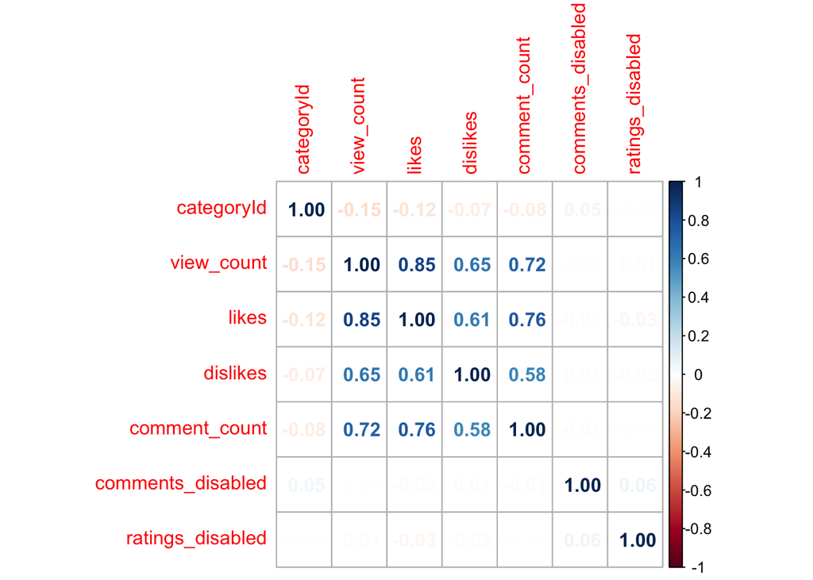

```r
install.packages("corrplot", repos = "http://cran.us.r-project.org")
library(corrplot)
mx_dataset$comments_disabled <- as.numeric(as.logical(mx_dataset$comments_disabled))
mx_dataset$ratings_disabled <- as.numeric(as.logical(mx_dataset$ratings_disabled))

numeric_mx_dataset <- Filter(is.numeric, mx_dataset)
numeric_mx_dataset.cor <- cor(numeric_mx_dataset)
corrplot(numeric_mx_dataset.cor, method = 'number')
```

No se identifica ninguna correlación negativa imporante entre las columnas, pero si se identifican al menos 2 correlaciones positivas importantes: la presente entre la cantidad de visitas y likes, y la presente entre la cantidad de likes y de comentarios del video.

A continuación se cargará un segundo dataset asociado al anterior que contiene la información de las categorías de los videos:

```r
install.packages("tidyverse", repos = "http://cran.us.r-project.org")
library(tidyverse)
library(jsonlite)
mx_list_categories <- fromJSON("./dataset/MX_category_id.json")
mx_categories <- data.frame(mx_list_categories)
head(mx_categories, n= 20)
```

|  | kind | etag | items.kind | items.etag | items.id | items.snippet |
| --- | --- | --- | --- | --- | --- | --- |
| 1 | youtube#videoCategoryListResponse | kBCr3I9kLHHU79W4Ip5196LDptI | youtube#videoCategory | IfWa37JGcqZs-jZeAyFGkbeh6bc | 1 |  |
| 2 | youtube#videoCategoryListResponse | kBCr3I9kLHHU79W4Ip5196LDptI | youtube#videoCategory | 5XGylIs7zkjHh5940dsT5862m1Y | 2 |  |
| 3 | youtube#videoCategoryListResponse | kBCr3I9kLHHU79W4Ip5196LDptI | youtube#videoCategory | HCjFMARbBeWjpm6PDfReCOMOZGA | 10 |  |
| 4 | youtube#videoCategoryListResponse | kBCr3I9kLHHU79W4Ip5196LDptI | youtube#videoCategory | ra8H7xyAfmE2FewsDabE3TUSq10 | 15 |  |
| 5 | youtube#videoCategoryListResponse | kBCr3I9kLHHU79W4Ip5196LDptI | youtube#videoCategory | 7mqChSJogdF3hSIL-88BfDE-W8M | 17 |  |
| 6 | youtube#videoCategoryListResponse | kBCr3I9kLHHU79W4Ip5196LDptI | youtube#videoCategory | 0Z6uGkj97NgjD-X3pkA-nL18Hqk | 18 |  |
| 7 | youtube#videoCategoryListResponse | kBCr3I9kLHHU79W4Ip5196LDptI | youtube#videoCategory | K_-7stg0kIU7eUBOPUa6j5fqIMQ | 19 |  |
| 8 | youtube#videoCategoryListResponse | kBCr3I9kLHHU79W4Ip5196LDptI | youtube#videoCategory | I3IL9xGIM3MsULlqR4tvCsEKv98 | 20 |  |
| 9 | youtube#videoCategoryListResponse | kBCr3I9kLHHU79W4Ip5196LDptI | youtube#videoCategory | D1W6tq5mMMCV0wtNxf9A6g9wWjU | 21 |  |
| 10 | youtube#videoCategoryListResponse | kBCr3I9kLHHU79W4Ip5196LDptI | youtube#videoCategory | QMEBz6mxVdklVaq8JwesPEw_4nI | 22 |  |

[output cut: 10 more lines]

El archivo **MX_category_id.json** contiene las categorías (*categoryId*) a la que puede pertenecer cada uno de los videos. Las columnas de este archivo son las siguientes:

- kind (La clase correspondiente al dato, en este caso fijada a “youtube#videoCategoryListResponse”)
- etag (Texto que corresponde al http etag de este recurso)
- id (Texto, la identificación única que YouTube usa para identificar la categoría)
- snippet (Detalles básicos de la categoría en cuestión)
- title (Descripción de la categoría)
- assignable (Valor booleano que denota si la categoría puede ser asiganda)
- channelId (Identificador del canal único que YouTube otorga a esta categoría)

Las dimensiones de este dataset son, 31 filas y 6 columnas.

```r
dim(mx_categories)
```

```
## [1] 31  6
```

La columna *items.snippet* del dataset de categorías es de tipo *data.frame*, es decir, cada fila del conjunto contiene otro *data.frame* en el valor de la columna *items.snippet*.

```r
class(mx_categories$items.snippet)
```

```
## [1] "data.frame"
```

```r
head(mx_categories$items.snippet)
```

|  | title | assignable | channelId |
| --- | --- | --- | --- |
| 1 | Film & Animation | TRUE | UCBR8-60-B28hp2BmDPdntcQ |
| 2 | Autos & Vehicles | TRUE | UCBR8-60-B28hp2BmDPdntcQ |
| 3 | Music | TRUE | UCBR8-60-B28hp2BmDPdntcQ |
| 4 | Pets & Animals | TRUE | UCBR8-60-B28hp2BmDPdntcQ |
| 5 | Sports | TRUE | UCBR8-60-B28hp2BmDPdntcQ |
| 6 | Short Movies | FALSE | UCBR8-60-B28hp2BmDPdntcQ |

En total este dataset contiene 30 categorías, a continuación se listan todas las categorías:

```r
unique(mx_categories$items.snippet$title)
```

```
##  [1] "Film & Animation"     "Autos & Vehicles"     "Music"
##  [4] "Pets & Animals"       "Sports"               "Short Movies"
##  [7] "Travel & Events"      "Gaming"               "Videoblogging"
## [10] "People & Blogs"       "Comedy"               "Entertainment"
## [13] "News & Politics"      "Howto & Style"        "Education"
## [16] "Science & Technology" "Movies"               "Anime/Animation"
## [19] "Action/Adventure"     "Classics"             "Documentary"
## [22] "Drama"                "Family"               "Foreign"
## [25] "Horror"               "Sci-Fi/Fantasy"       "Thriller"
## [28] "Shorts"               "Shows"                "Trailers"
```

El dataset *mx_dataset* contiene valores nulos o en blanco en las columna *description* y *tags*. Se encontraron 6819 valores faltantes en la columna *description* y 20407 en la columna *tags*.

```r
null_values_dataset <- sapply(mx_dataset, function(x) is.na(x) | x == "" | x == "[None]")
colSums(null_values_dataset)
```

```
##          video_id             title       publishedAt         channelId
##                 0                 0                 0                 0
##      channelTitle        categoryId     trending_date              tags
##                 0                 0                 0             20407
##        view_count             likes          dislikes     comment_count
##                 0                 0                 0                 0
##    thumbnail_link comments_disabled  ratings_disabled       description
##                 0                 0                 0              6819
```

El dataset *mx_categories* no contiene valores nulos o en blanco en ninguna de sus columnas. Esto incluye las columnas que se encuentran dentro del dataframe de la columna *items.snippet*.

```r
sapply(mx_categories, function(x) any(is.na(x) | x == ""))
```

```
##          kind          etag    items.kind    items.etag      items.id
##         FALSE         FALSE         FALSE         FALSE         FALSE
## items.snippet
##         FALSE
```

## Cantidad de videos por categoria

La cantidad de videos que tiene cada categoría para el dataset de México se presenta en el siguiente gráfico:

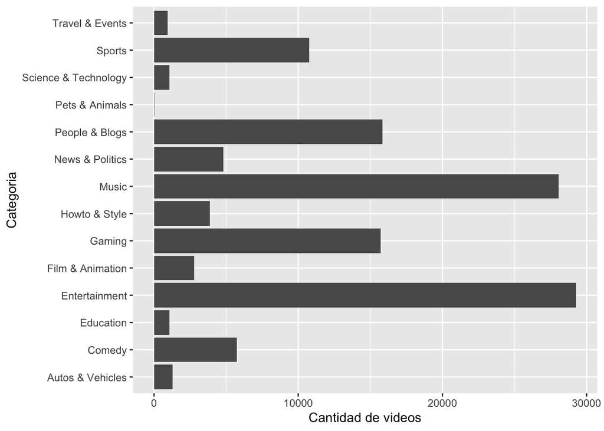

```r
library(ggplot2)
aux_categories <- data.frame(categoryId = mx_categories$items.id , categoryTitle = mx_categories$items.snippet$title)
mx_dataset <- merge(mx_dataset, aux_categories)

ggplot(mx_dataset, aes(x = categoryTitle)) +
  geom_bar(stat = 'count') +
  coord_flip() +
  xlab("Categoria") + ylab("Cantidad de videos")
```

Un análisis a simple vista del gráfico denota que existen dos categorías que acumulan la mayor cantidad de videos: Music y Entertainment. Podemos obtener el promedio de la cantidad de videos por categoría:

```r
#Se obtiene la cantidad de videos por cada categoría

travel_and_events <- nrow(mx_dataset[mx_dataset$categoryId == 19,])
sports <- nrow(mx_dataset[mx_dataset$categoryId == 17,])
science_and_technology <- nrow(mx_dataset[mx_dataset$categoryId == 28,])
pets_and_animals <- nrow(mx_dataset[mx_dataset$categoryId == 15,])
people_and_blogs <- nrow(mx_dataset[mx_dataset$categoryId == 22,])
news_and_politics <- nrow(mx_dataset[mx_dataset$categoryId == 25,])
music <- nrow(mx_dataset[mx_dataset$categoryId == 10,])
howto_and_style <- nrow(mx_dataset[mx_dataset$categoryId == 26,])
gaming <- nrow(mx_dataset[mx_dataset$categoryId == 20,])
film_and_animation <- nrow(mx_dataset[mx_dataset$categoryId == 1,])
entertainment <- nrow(mx_dataset[mx_dataset$categoryId == 24,])
education <- nrow(mx_dataset[mx_dataset$categoryId == 27,])
comedy <- nrow(mx_dataset[mx_dataset$categoryId == 23,])
autos_and_vehicles <- nrow(mx_dataset[mx_dataset$categoryId == 2,])

#Se crea un vector que contiene todas las categorías con su cantidad de videos
categoria <- c(travel_and_events, sports, science_and_technology, pets_and_animals, people_and_blogs, news_and_politics, music, howto_and_style, gaming, film_and_animation, entertainment, education, comedy, autos_and_vehicles)

#Se obtiene el promedio de videos por categoria
mean(categoria)
```

```
## [1] 8661.143
```

```r
#Se obtiene la media de la cantidad de videos por categoría
median(categoria)
```

```
## [1] 4352.5
```

Se obtiene un valor de 8661 videos por categoría en promedio. Pero debido a que este dos categorías contienen la mayor cantidad de videos este valor es deceptivo. Tambien al considerar la media se obtiene el valor de 4352. Dónde se considera que la mitad de las categorías estan bajo ese valor (en cantidad de videos) y la otra mitad sobre ese mismo valor.

## Cantidad de likes, dislikes y comentarios

Dentro del análisis exploratorio de los datos se contempla un análisis sobre los likes, dislikes y comentarios para el dataset de trendings de México.

```r
mean(mx_dataset$view_count)
```

```
## [1] 2251101
```

### Visitas vs likes

La cantidad de las visitas vs likes se presenta en el siguiente gráfico de disperción:

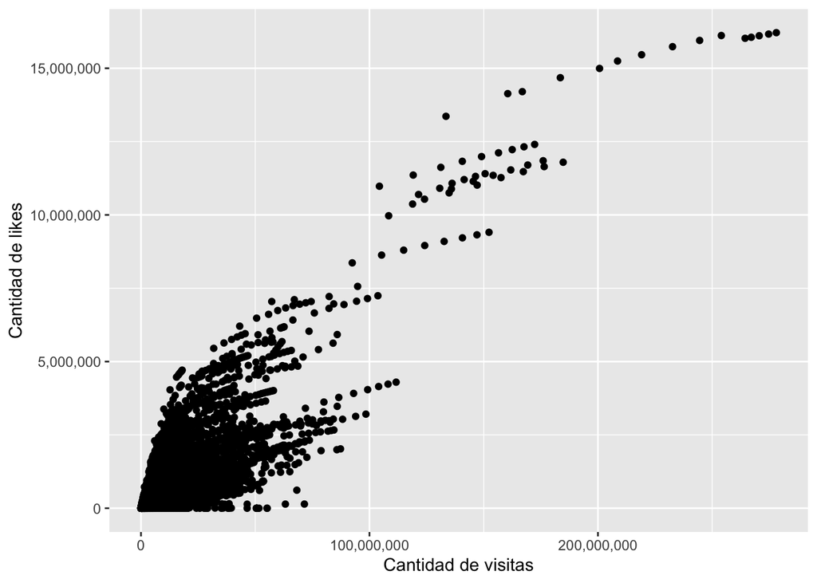

```r
ggplot(mx_dataset, aes(x = view_count, y = likes)) +
  geom_point() +
  scale_y_continuous(labels = scales::comma) +
  scale_x_continuous(labels = scales::comma) +
  xlab("Cantidad de visitas") + ylab("Cantidad de likes")
```

Donde se aprecia que a medida que las visitas aumentan, la cantidad de likes tambien aumenta, y se percibe al observar el gráfico que su comportamiento podría ser lineal.

```r
mean(mx_dataset$likes)
```

```
## [1] 160573
```

### Visitas vs dislikes

La cantidad de las visitas vs dislikes se presenta en el siguiente gráfico de disperción:

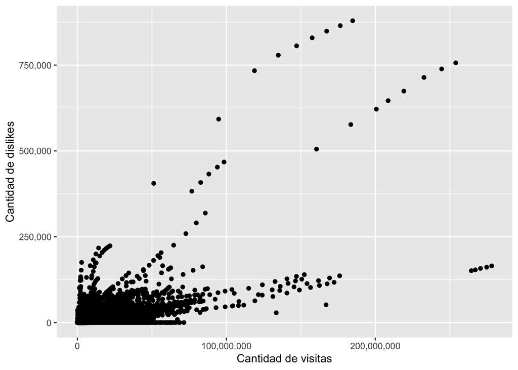

```r
ggplot(mx_dataset, aes(x = view_count, y = dislikes)) +
  geom_point() +
  scale_y_continuous(labels = scales::comma) +
  scale_x_continuous(labels = scales::comma) +
  xlab("Cantidad de visitas") + ylab("Cantidad de dislikes")
```

En este gráfico ocurre una situación interesante. Si bien a medida que los videos obtienen mayor vista tambien lo hacen los dislikes, se puede apreciar que la cantidad de dislikes oscina en la mitad de la muestra, y posteriormente se observa una baja de estos dislikes en los videos más vistos.

```r
mean(mx_dataset$dislikes)
```

```
## [1] 2324.458
```

### Visitas vs comentarios

La cantidad de visitas vs cantidad de comentarios se presenta de la siguiente manera:

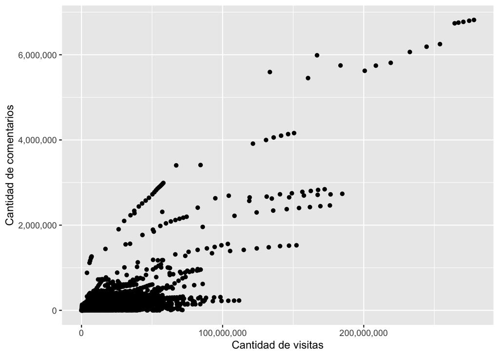

```r
ggplot(mx_dataset, aes(x = view_count, y = comment_count)) +
  geom_point() +
  scale_y_continuous(labels = scales::comma) +
  scale_x_continuous(labels = scales::comma) +
  xlab("Cantidad de visitas") + ylab("Cantidad de comentarios")
```

Para este caso, la cantidad de comentarios oscila en mayor medida que en los casos anteriores en la mitad de la muestra, no obteniendo un patrón claro, pero a medida que la cantidad de vistas aumenta, la cantidad de comentarios también lo hacen, observablemente en el gráfico, de manera lineal.

```r
mean(mx_dataset$comment_count)
```

```
## [1] 11995.63
```

### Resumen final de visitas

```r
data.frame(Atributo = c("visitas","likes","dislikes", "comentarios"), Promedio = c(mean(mx_dataset$view_count),mean(mx_dataset$likes),mean(mx_dataset$dislikes),mean(mx_dataset$comment_count)))
```

| Atributo | Promedio |
| --- | --- |
| visitas | 2251100.843 |
| likes | 160573.042 |
| dislikes | 2324.458 |
| comentarios | 11995.633 |

Como resultado, para el caso de México se aprecia que la cantidad de likes corresponde a casi 70 veces más que la cantidad de dislikes, además de que la cantidad de comentarios es muy superior a la cantidad de dislikes. Lo anterior corresponde a un indicativo de la participación de los usuarios en México sobre los videos tanto positivos como negativos, donde los usuarios mexicanos interactúan de forma mayormente positiva a los videos más vistos.

## Comparativa de canales

A continuación se realizará un análisis a los 10 canales con mayor cantidad de videos en la lista de trendings para el dataset de trendings de México.

### Videos en la lista de trendings

Gráfico de top 10 canales con mas videos en la lista de trendings:

```r
top_10 <- group_by(mx_dataset, channelTitle) |>
  summarize(Freq = n()) |>
  arrange(desc(Freq)) |>
  top_n(10)
top_10
```

| channelTitle | Freq |
| --- | --- |
| TUDN México | 1095 |
| Marca Claro | 675 |
| Luisito Comunica | 667 |
| Cracks | 571 |
| Kimberly Loaiza | 570 |
| FOX Sports MX | 547 |
| Más SKabeche | 544 |
| BANGTANTV | 517 |
| Andrés Manuel López Obrador | 471 |
| LosPolinesios | 459 |

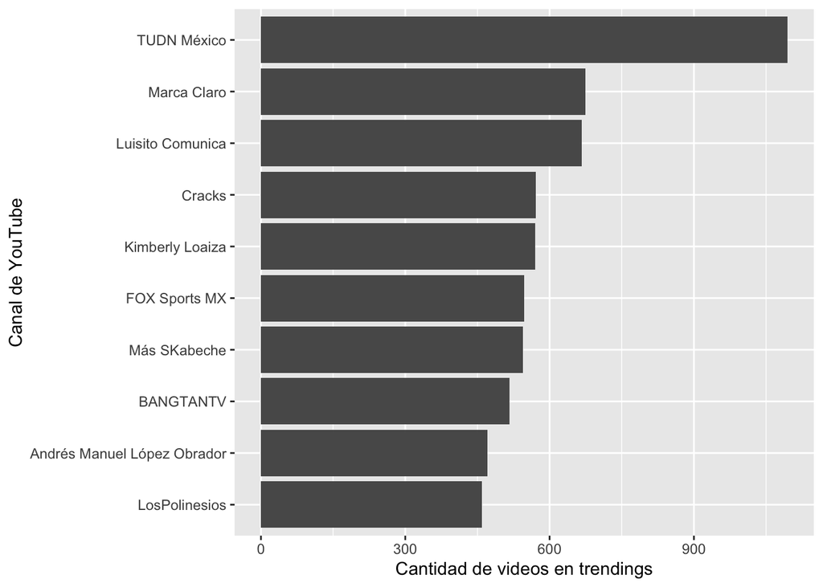

```r
ggplot(top_10, aes(x = reorder(channelTitle, Freq), y = Freq)) +
  geom_bar(stat = 'identity') +
  coord_flip() +
  xlab('Canal de YouTube') +
  ylab('Cantidad de videos en trendings')
```

### Likes y dislikes de videos en trendings

Gráfico de acumulacion de cantidad de likes y dislikes del top 10 canales con mas videos en trendings:

```r
install.packages("gridExtra", repos = "http://cran.us.r-project.org")
library(gridExtra)
library("scales")
```

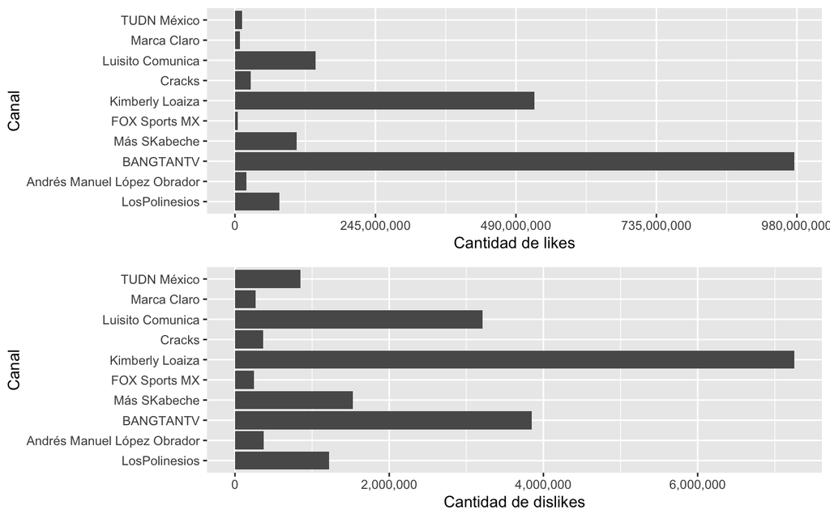

```r
top_10_accumulations <- group_by(mx_dataset, channelTitle) |>
  summarize(Freq = n(), likes = sum(likes), dislikes = sum(dislikes)) |>
  arrange(desc(Freq)) |>
  top_n(10, Freq)

likes_plot <- ggplot(top_10_accumulations,aes(x = reorder(channelTitle, Freq),y = likes)) +
  geom_bar(stat = 'identity') +
  coord_flip() +
  scale_y_continuous(labels = scales::comma, breaks = c(0, 245000000, 490000000, 735000000, 980000000)) +
  xlab("Canal") + ylab("Cantidad de likes")

dislikes_plot <- ggplot(top_10_accumulations,aes(x = reorder(channelTitle, Freq),y = dislikes)) +
  geom_bar(stat = 'identity') +
  coord_flip() +
  scale_y_continuous(labels = scales::comma) +
  xlab("Canal") + ylab("Cantidad de dislikes")


grid.arrange(likes_plot, dislikes_plot)
```

### Mayor cantidad de likes

Gráfico de top 10 canales con mayor acumulación de likes:

```r
likes_accumulation <- group_by(mx_dataset, channelTitle) |>
  summarize(Accumulation = sum(likes)) |>
  arrange(desc(Accumulation)) |>
  top_n(10)
```

[figure not shown]

```r
ggplot(likes_accumulation, aes(x = reorder(channelTitle, Accumulation), y = Accumulation)) +
  scale_y_continuous(labels = scales::comma) +
  geom_bar(stat = 'identity') +
  coord_flip() +
  xlab('Canal de YouTube') +
  ylab('Cantidad de videos en trendings')
```

## Análisis comparativo de todos los países

Si bien el análisis exploratorio inicial se realizó tomando el dataset correspondiente a México, existen muchos otros países dentro del dataset de trendings de YouTube, por lo cual se realizan algunos análisis generales a continuación.

Primero se cargan cada uno de los dataset de los países leyendo el archivo correspondiente.

```r
mx_dataset <- read.csv("./dataset/MX_youtube_trending_data.csv", encoding = "UTF-8")
us_dataset <- read.csv("./dataset/US_youtube_trending_data.csv", encoding = "UTF-8")
br_dataset <- read.csv("./dataset/BR_youtube_trending_data.csv", encoding = "UTF-8")
ca_dataset <- read.csv("./dataset/CA_youtube_trending_data.csv", encoding = "UTF-8")
de_dataset <- read.csv("./dataset/DE_youtube_trending_data.csv", encoding = "UTF-8")
fr_dataset <- read.csv("./dataset/FR_youtube_trending_data.csv", encoding = "UTF-8")
```

```
## Warning in scan(file = file, what = what, sep = sep, quote = quote, dec = dec, :
## embedded nul(s) found in input
```

```r
gb_dataset <- read.csv("./dataset/GB_youtube_trending_data.csv", encoding = "UTF-8")
in_dataset <- read.csv("./dataset/IN_youtube_trending_data.csv", encoding = "UTF-8")
jp_dataset <- read.csv("./dataset/JP_youtube_trending_data.csv", encoding = "UTF-8")
```

```
## Warning in scan(file = file, what = what, sep = sep, quote = quote, dec = dec, :
## embedded nul(s) found in input
```

```r
kr_dataset <- read.csv("./dataset/KR_youtube_trending_data.csv", encoding = "UTF-8")
ru_dataset <- read.csv("./dataset/RU_youtube_trending_data.csv", encoding = "UTF-8")
```

El interprete indica que se encontraron valores nulos en los archivos de Francia y Japón. No realizamos ninguna acción frente a esta advertencia ya que solamente es una advertencia y es posible cargar correctamente el resto de los datos.

A continuación agregamos una columna llamada *country* a cada dataset para identificar el archivo (país) del que se obtuvo cada fila. Esto sera de utilidad para análisis posteriores.

```r
mx_dataset$country <- "MX"
us_dataset$country <- "US"
br_dataset$country <- "BR"
ca_dataset$country <- "CA"
de_dataset$country <- "DE"
fr_dataset$country <- "FR"
gb_dataset$country <- "BG"
in_dataset$country <- "IN"
jp_dataset$country <- "JP"
kr_dataset$country <- "KR"
ru_dataset$country <- "RU"
```

Finalmente se unen todos los datos en un único dataframe para simplificar los análisis comparativos posteriores.

```r
dataset <- rbind(mx_dataset, us_dataset, br_dataset, ca_dataset, de_dataset, fr_dataset, gb_dataset, in_dataset, jp_dataset, kr_dataset, ru_dataset)
```

### Cantidad de videos en trending por país

El siguiente gráfico muestra la cantidad de videos en trending por cada país, es decir, la cantidad de filas que contiene cada uno de los archivos leídos.

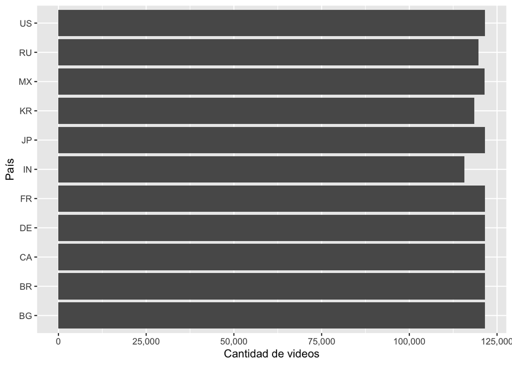

```r
videos_amount <- group_by(dataset, country) |>
  summarize(amount = n())

ggplot(videos_amount, aes(x = country, y = amount)) +
  geom_bar(stat = 'identity') +
  scale_y_continuous(labels = scales::comma) +
  coord_flip() +
  xlab("País") + ylab("Cantidad de videos")
```

Se puede observar que la mayoría de países tiene una cantidad parecida de videos. Esto indica que los conjuntos de datos de cada país tienen semejante cantidad de datos, excepto en los casos de Rusia, Corea e India. Los valores exactos de cantidad de videos por cada país se muestran en la siguiente tabla:

```r
arrange(videos_amount, desc(amount))
```

| country | amount |
| --- | --- |
| BG | 121595 |
| BR | 121592 |
| FR | 121591 |
| US | 121591 |
| JP | 121587 |
| CA | 121544 |
| DE | 121543 |
| MX | 121399 |
| RU | 119665 |
| KR | 118554 |

[output cut: 1 more lines]

### Cantidad de visitas por pais

La cantidad de visitas de todos los videos en la lista de trendings por país se presenta en el siguiente gráfico:

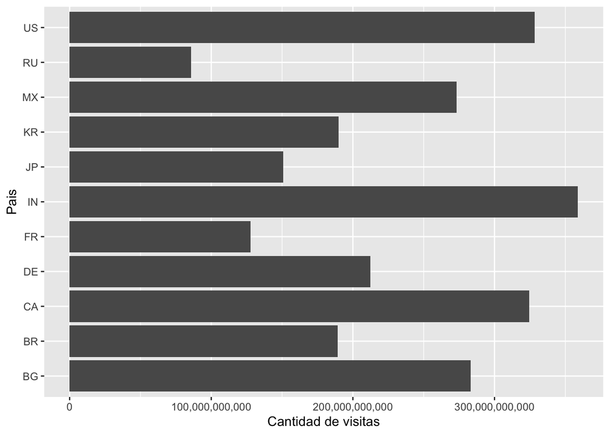

```r
view_count <- group_by(dataset, country) |>
  summarize(views = sum(view_count))

ggplot(view_count, aes(x = country, y = views)) +
  geom_bar(stat = 'identity') +
  scale_y_continuous(labels = scales::comma) +
  coord_flip() +
  xlab("Pais") + ylab("Cantidad de visitas")
```

Los valores reales por país se muestran en la siguiente tabla:

```r
arrange(view_count, desc(views))
```

| country | views |
| --- | --- |
| IN | 358915195319 |
| US | 328297983860 |
| CA | 324491580308 |
| BG | 283134799392 |
| MX | 273102109265 |
| DE | 212396451128 |
| KR | 189795663834 |
| BR | 189308405016 |
| JP | 150921711511 |
| FR | 127797915943 |

[output cut: 1 more lines]

Los resultados de este análisis son interesantes, ya que el país que mas visitas totales acumula es India, el país cuyo conjunto de datos contiene la menor cantidad de registros de dataset completo.

### Canales con mas videos en la lista de tendencias

El siguiente gráfico muestra el top 10 de los canales que tienen mas videos en las listas de tendencias de todos los países. Este análisis contempla el periodo temporal total del conjunto de datos.

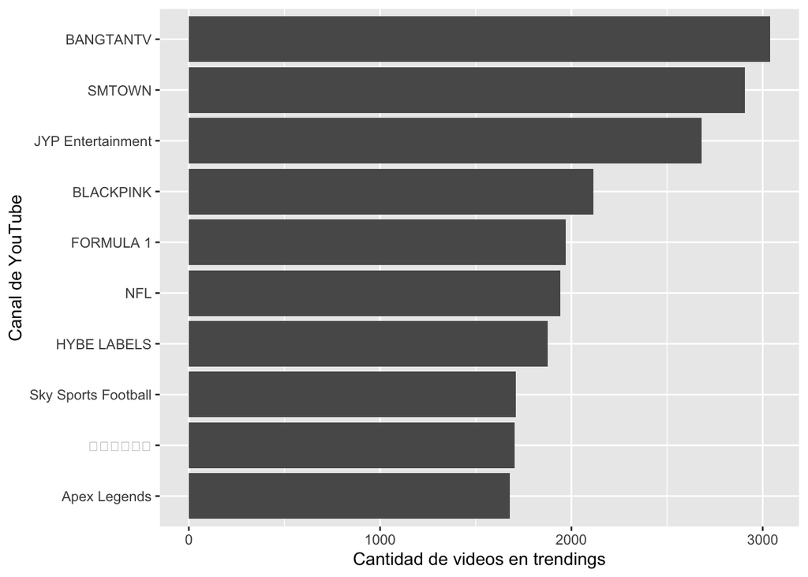

```r
top_10_global <- group_by(dataset, channelTitle) |>
  summarize(Freq = n(), country = first(country)) |>
  arrange(desc(Freq)) |>
  top_n(10, Freq)

ggplot(top_10_global, aes(x = reorder(channelTitle, Freq), y = Freq)) +
  geom_bar(stat = 'identity') +
  coord_flip() +
  xlab('Canal de YouTube') +
  ylab('Cantidad de videos en trendings')
```

# Preguntas y problemas

## Preguntas

En base a los resultados obtenidos de los análisis realizados y teniendo en cuenta la motivacion descrita al inicio de este documento, nos planteamos dar respuesta a las siguientes preguntas:

1. ¿Existe un patrón en las portadas de videos de los canales más famosos?

*Argumentación*: Es importante identificar si las portadas de videos son relevantes para obtener un video en trending, ya que son de las primeras cosas que se ven en un video, incluso antes del contenido del mismo.

2. ¿Existe una cultura general de YouTube que determina las tendencias de los videos, o depende netamente de la cultura del país de dónde se origina?

*Argumentación*: Lo anterior haría referencia a que la popularidad de un video podría depender o no depender del pais de donde se origina.

3. ¿Se pueden predecir la cantidad de visitas que tendrá un video?

*Argumentación*: Un posible punto de partida para esta pregunta es tomar en consideración el tiempo entre el ingreso de cada video en los trendings en el dataset.

## Problemas

No existe una estandarización del concepto “interacción” para un determinado vídeo. Ya que un video “famoso” se compone por una cierta cantidad de interacciones, que están formadas por likes, dislikes, visitas y comentarios. No se identifica cual de estos criterios tiene mayor o igual valor a los otros.

# Repositorio GitHub

El proyecto se documenta en un repositorio de GitHub, donde se podrá acceder en el siguiente link:

[Repositorio de Github](https://github.com/Jjaraa/yt-trending)

# Lista de presentaciones

Se agregarán los links para acceder a los videos de las presentaciones del proyecto en la lista a continuación:

[Presentación Hito 1](https://drive.google.com/file/d/1FtXd9IpnTddy92ABYJQkYAO-QjKWWMUk/view?usp=sharing)

# Responsabilidades del grupo de trabajo

**Sebastian Pardo**: Estuvo a cargo de la redacción de las secciones: Introducción y Preguntas y Problemas. Se encargó del desarrollo del análisis inicial del archivo *MX_category_id.json*, la matriz de correlación del dataset de Mexico y los gráficos: *Cantidad de videos por categoría*, *Visitas vs likes*, *Visitas vs dislikes*, *Visitas vs comentarios*, *Top 10 canales con mas videos*, *Matriz de correlación entre los atributos*, *Cantidad de videos en trending por país*, *Cantidad de visitas por país* y *Canales con mas videos en la lista de tentendias (global)* . Finalmente se hizo cargo del desarrollo de la subsección *Análisis comparativo de todos los países*

**Mauricio Campos**: Se encargó de redactar y explicar cada columna del dataset usado para el desarrollo del informe (mx_dataset y MX_category_id). También se encargó del desarrollo exploratorio de la sección *Cantidad de videos por categoria*.

**Jonathan Jara**: Se encargó del análisis de las subsecciones de *Visitas vs likes*, *Visitas vs dislikes*, *Visitas vs comentarios*, de planificar la estructura de trabajo con el versionamiento en el repositorio, de la estructura general del informe, creación de secciones y subsecciones, argumentación de la sección Preguntas y Problemas para las preguntas y planteamiento para el problema identificado. También se encargó de sintentizar los resultados del analisis exploratorio para las subsecciones analizadas por el en la subseccion *Resumen final de visitas*.

# Referencias

[1] https://www.statista.com/statistics/272014/global-social-networks-ranked-by-number-of-users/

[2] https://www.statista.com/forecasts/1144088/youtube-users-in-the-world

[3] https://www.statista.com/statistics/195140/new-user-generated-content-uploaded-by-users-per-minute/

[4] https://www.statista.com/statistics/259477/hours-of-video-uploaded-to-youtube-every-minute/

[5] https://support.google.com/youtube/answer/7239739?hl=es-419